# Problem Set 6

Author

Answer Key

Published

Invalid Date

```r
# load packages, they are all installed for you already (in the cloud only)
library(tidyverse) # your friend and mine
library(broom) # for tidy regression
library(modelsummary) # for nice regression tables
library(fixest) # for fixed effects and 2SLS/IV regression
library(car) # for f-test
library(dagitty) # for dags
library(ggdag) # for plotting dags
library(ggraph) # for plotting dags
```

# Theory and Concepts

## Question 1

In your own words, describe what *fixed effects* are, when we can use them, and how they remove endogeneity.

Fixed effects can be used for panel data, where each observation$_{it}$ belongs to a group $i$ and a time period $t$. Running a simple OLS model as usual, known as a **pooled model** would be biased due to systematic relationships within and between groups and time periods that cause $X_{it}$ to be endogenous:

$$\hat{Y}_{it}=\beta_0+\beta_1 X_{it}+u_{it}$$

Group-fixed effects $(\alpha_i$) pull out of the error term all of the factors that explain $Y_{it}$ that are stable over time within each individual group ($i$), but vary across groups. For example, if groups are U.S. states, state-fixed effects pull out all of the error term all of the idiosyncrasies of each state that do not change over time, such as cultural differences, geographical differences, historical differences, population differences, etc. Group fixed effects *do not* pull out factors that change over time, such as federal laws passed, recessions affecting all states, etc.

Time-fixed effects $(\theta_i)$ pull out of the error term all of the factors that explain $Y_{it}$ that change over time but do not vary across groups. For example, if groups are U.S. states, and time is in years, year-fixed effects pull out all of the error term all of the changes over the years that affect all U.S. states, such as recessions, inflation, national population growth, national immigration trends, or federal laws passed that affect all states. Time-fixed effects *do not* pull out factors that do not change over time.

$$\hat{Y}_{it}=\beta_0+\beta_1 X_{it}+ \alpha_{i} + \theta_{t} + \epsilon_{it}$$

Mechanically, OLS estimates a separate constant for each group (and/or each time period), giving the expected value of $Y_{it}$ for that group or time-period. This can be done by either de-meaning the data and calculating OLS coefficients by exploiting the variation *within* each group and/or time period (which is why fixed effects estimators are called “within” estimators), or by creating a dummy variable for each group and/or time period (and omitting one of each, to avoid the dummy variable trap).

## Question 2

In your own words, describe the logic of a *difference-in-difference* model: what is it comparing against what, and how does it estimate the effect of treatment? What assumption must be made about the treatment and control group for the model to be valid?

$$\hat{Y}_{it}=\beta_0+\beta_1 \, \text{Treated}_i +\beta_2 \, \text{After}_{t}+\beta_3 \, (\text{Treated}_i \times \text{After}_{t})+u_{it}$$

A difference-in-difference model compares the difference before and after a treatment between a group that receives the treatment and a group that does not. By doing so, we can isolate the effect of the treatment. It is easiest to see in the following equation:

$$\Delta \Delta Y = (\text{Treated}_{\text{after}}-\text{Treated}_{\text{before}})-(\text{Control}_{\text{after}}-\text{Control}_{\text{before}})$$

In OLS regression, we can simply make two dummy variables for observations$_it$ depending on the group and the time period each observation is:

$$\text{Treated}_i = \begin{cases}
1 & \text{if } i \text{ receives treatment} \\
0 & \text{if } i \text{ does not receive treatment }\\
\end{cases}$$

$$\text{After}_t = \begin{cases}
1 & \text{if } t \text{is after treatment period} \\
0 & \text{if } t \text{is before treatment period}\\
\end{cases}$$

Lastly, we make an interaction term $\text{Treated}_i \times \text{After}_t$ which isolates the treatment effect, captured by the coefficient on this term, $\beta_3$.

Diff-in-diff models assume a counterfactual that if the treated group did not receive treatment, it would have experience the same change as the control group over the pre- to post-treatment period.

A classic example is if a state(s) passes a law and others do not. We want to compare the difference in the difference before and after the law was passed between states that passed the law and states that did not:

$$\Delta_i \Delta_t Outcome = (\text{Passed}_{after}-\text{Passed}_{before})-(\text{Didn't}_{after}-\text{Didn't}_{before})$$

[output not shown]

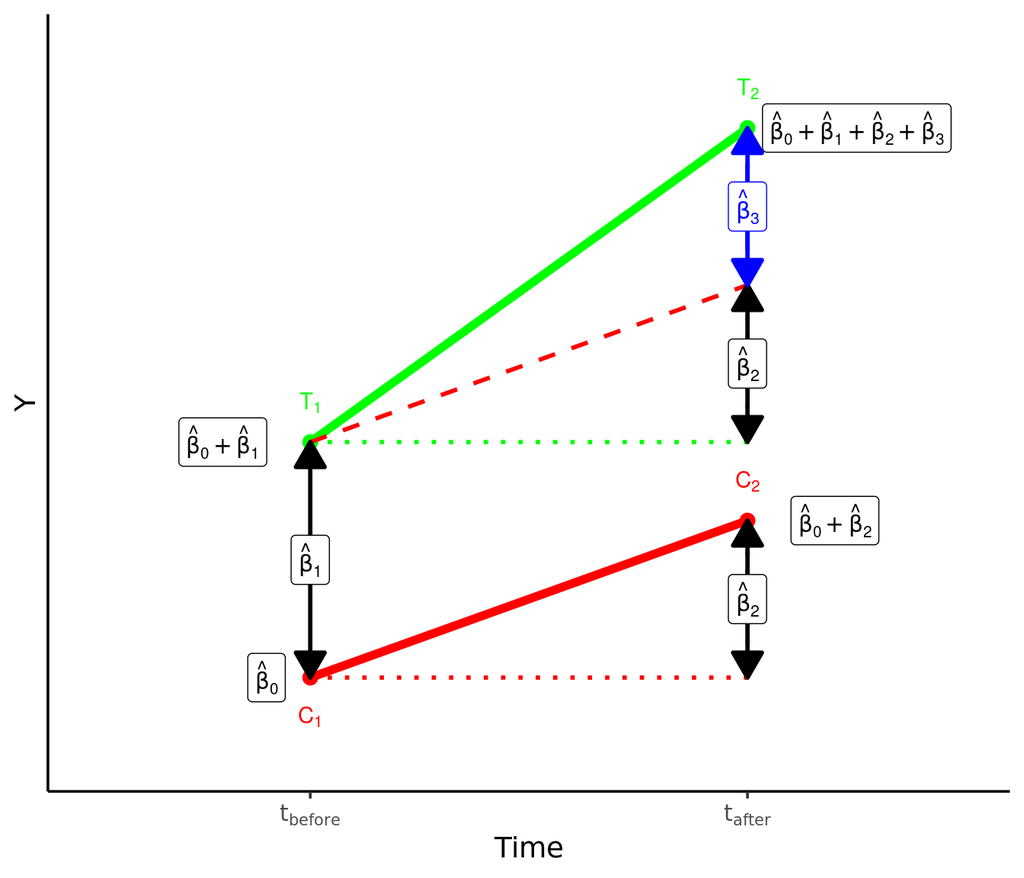

```r
control<-tribble(
  ~x, ~y,
  1, 1,
  2, 3
)
treatment<-tribble(
  ~x, ~y,
  1, 4,
  2, 8
)

ggplot(data = tibble(x=1,3))+
  aes(x = x)+
  # control
  geom_point(data = control, aes(x=x,y=y), size = 3, color = "red")+
  geom_text(x=1,y=0.5, color = "red", label=expression(C[1]))+
  geom_text(x=2,y=3.5, color = "red", label=expression(C[2]))+

  # line
  geom_segment(x=1, y=1, xend=2, yend=3, color="red", size = 2)+

  # beta 0
  geom_label(x=0.9,y=1, color = "black", label=expression(hat(beta)[0]))+

  # line slope
  geom_segment(x=1, y=1, xend=2, yend=1, color="red", linetype = "dotted", size = 1)+
  geom_segment(x=2, y=1, xend=2, yend=3, color="red", linetype = "dotted", size = 1)+
  # beta 1+2
  geom_label(x=2.2,y=3, color = "black", label=expression(hat(beta)[0]+hat(beta)[2]))+

  # treatment
  geom_point(data = treatment, aes(x=x,y=y), size = 3, color = "green")+
  geom_text(x=1,y=4.5, color = "green", label=expression(T[1]))+
  geom_text(x=2,y=8.5, color = "green", label=expression(T[2]))+

    # line
  geom_segment(x=1, y=4, xend=2, yend=8, color="green", size = 2)+

  # beta 0 plus beta 1
  geom_label(x=0.8,y=4, color = "black", label=expression(hat(beta)[0]+hat(beta)[1]))+


  # line slope
  geom_segment(x=1, y=4, xend=2, yend=4, color="green", linetype = "dotted", size = 1)+
  geom_segment(x=2, y=4, xend=2, yend=6, color="red", linetype = "dotted", size = 1)+

  # diag
  geom_segment(x=1, y=4, xend=2, yend=6, color="red", linetype = "dashed", size = 1)+

  geom_segment(x=2, y=6, xend=2, yend=8, color="blue", linetype = "dashed", size = 1)+

  # beta 3
  geom_label(x=2.25,y=8, color = "black",
             label=expression(hat(beta)[0]+hat(beta)[1]+hat(beta)[2]+hat(beta)[3]))+

  # beta 1 dif
  annotate("segment", x = 1, xend = 1, y = 1, yend = 4, colour = "black", size=1, alpha=1, arrow=arrow(length=unit(0.5,"cm"), ends="both", type="closed"))+
  geom_label(x=1,y=2.5, size = 4, color = "black", label=expression(hat(beta)[1]))+

  # beta 2 dif
  annotate("segment", x = 2, xend = 2, y = 1, yend = 3, colour = "black", size=1, alpha=1, arrow=arrow(length=unit(0.5,"cm"), ends="both", type="closed"))+
  geom_label(x=2,y=2, size = 4, color = "black", label=expression(hat(beta)[2]))+

  # beta 2 dif
  annotate("segment", x = 2, xend = 2, y = 4, yend = 6, colour = "black", size=1, alpha=1, arrow=arrow(length=unit(0.5,"cm"), ends="both", type="closed"))+
  geom_label(x=2,y=5, size = 4, color = "black", label=expression(hat(beta)[2]))+

  # beta 2 dif
  annotate("segment", x = 2, xend = 2, y = 6, yend = 8, colour = "blue", size=1, alpha=1, arrow=arrow(length=unit(0.5,"cm"), ends="both", type="closed"))+
  geom_label(x=2,y=7, size = 4, color = "blue", label=expression(hat(beta)[3]))+

    scale_x_continuous(breaks=c(1,2),
                  labels=c(expression(t[before]),expression(t[after])),
                  limits=c(0.5,2.5))+
  scale_y_continuous(breaks=NULL,
                     limits=c(0,9))+
  labs(x = "Time",
       y = "Y")+
  theme_classic(base_family = "Fira Sans Condensed",
           base_size=14)
```

|  | Control | Treatment | **Group Diff** $(\Delta Y_i)$ |
| --- | --- | --- | --- |
| Before | $\beta_0$ | $\beta_0+\beta_1$ | $\beta_1$ |
| After | $\beta_0+\beta_2$ | $\beta_0+\beta_1+\beta_2+\beta_3$ | $\beta_1+\beta_3$ |
| **Time Diff** $(\Delta Y_t)$ | $\beta_2$ | $\beta_2+\beta_3$ | $\beta_3$ **Diff-in-diff** $(\Delta_i \Delta_t)$ |

## Question 3

In your own words, describe the logic of an *instrumental variables* model: how does this approach identify the causal effect of $X$ on $Y$? What makes for a valid instrument? When using a Two-Stage Least Squares approach, what is estimated at each stage?

Suppose we have a simple linear regression model of

$$Y_i = \beta_0 + \beta_1 \, X_i + u_i$$

Instrumental variables techniques attempt to isolate and use only the variation in an endogenous $X$ variable (correlated with the error term, other factors that cause $Y$) that is *exogenous*, that is, *not* correlated with the error term. This is done by using an *instrumental variable*, $I$ that is correlated with $X$, but not a direct cause of $Y$; only *indirectly*, through $X$, does it cause $Y$. Thus, there are two conditions for a valid instrument:

1. **Relevance** (the **“inclusion condition”**): instrument $I$ must be correlated with $X$.
2. **Exogeneity** (the **“exclusion condition”**): instrument $I$ must *not* be correlated with the error term, $u$.

The first condition is testable with a *“first stage”* regression of $X$ on the instrument(s) $I$ (and any covariates, $X_2, \cdots X_k$):

$$X_i = \gamma_0 + \gamma_1 I_i + w_i$$
If $\gamma_1$ is statistically significant (i.e. we can reject $H_0$: $\gamma_1 = 0$), we have good evidence that the instrument is relevant.

The second condition is *not* testable statistically, and requires a plausible argument that $I$ does not cause $Y$ *except* through $X$.

We also run the *“reduced form*” regression of the instrument $I$ on outcome $Y$ (and any covariates):

$$Y_i = \pi_0 + \pi_1 I_i + v_i$$

The instrumental variable estimator for the original $\beta_1$, $\beta_1^{IV} = \frac{pi_1}{\gamma_1}$, that is, we scale the “direct” effect of $I \rightarrow Y$ ($\pi_1$) by the effect of $I \rightarrow X$ ($\gamma_1$), since it is only $X$ that directly affects $Y$, not $I$.

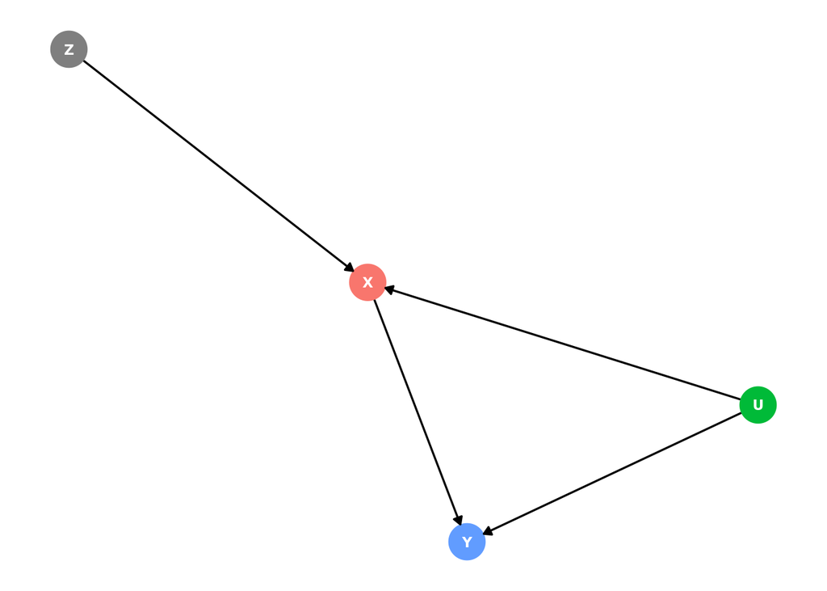

```r
iv_colors <- tribble(
  ~name, ~Variable, ~Type,
  "X", "X", "Endogenous",
  "Y", "Y", "Outcome",
  "I", "Z", "Exogenous",
  "U", "Z", "Exogenous",
)

iv_dag <- dagify(Y ~ X + U,
              X ~ Z + U,
              outcome = "Y",
              exposure = "X") %>%
  tidy_dagitty(seed = 256)

# Add node types/colors to DAG data
iv_dag$data <- iv_dag$data %>%
  left_join(iv_colors, by = "name")

iv_plot<-ggplot(data = iv_dag)+
  aes(x = x,
      y = y,
      xend = xend,
      yend = yend)+
  geom_dag_point(size = 10,
                 aes(color = Type)) +
  geom_dag_edges(start_cap = circle(4, "mm"),
                 end_cap = circle(4, "mm")) +
  geom_dag_text(size = 3, family = "Fira Sans") +
  scale_dag()+
  theme_void()+
  scale_shape_manual(values = c(16,17))+
  theme(legend.position = "none")
iv_plot
```

We can generalize this, if we want to use multiple endogenous variables and/or multiple instruments, with *Two Stage Least Squares (2SLS)*. We run the first stage regression of the endogenous variable $X$ on the instrument(s) $I$:

$$X_i = \gamma_0 + \gamma_1 I_i + w_i$$

Then we take the predicted (or fitted) values of $\hat{X_i}$ from the first stage, and substitute them in for our exogenous variable $X$ in the *second stage* regression:

$$Y_i = \beta_0 + \beta_1 \, \hat{X}_i + u_i$$
This gives us an unbiased estimator of $\beta_1$, so long as the instrument(s) is valid.

# R Questions

Answer the following questions using `R`. When necessary, please write answers in the same document (rendered to `html` or `pdf`, typed `.doc(x)`, or handwritten) as your answers to the above questions. Be sure to include (email or print an `.R` file, or show in your rendered quarto document) your code and the outputs of your code with the rest of your answers.

## Question 4 (Fixed Effects)

- [`PeaceCorps.csv`](http://metricsf22.classes.ryansafner.com/files/data/PeaceCorps.csv)

Download and read in `PeaceCorps.csv` dataset. If you don’t want to download/upload it, you can read it in directly from the url by running this chunk:

```r
# run or edit this chunk
pc <- read_csv("http://metricsf22.classes.ryansafner.com/files/data/PeaceCorps.csv")
```

How do people respond to changes in economic conditions? Are they more likely to pursue public service when private sector jobs are scarce? This dataset contains variables at the U.S. State (& D.C.) level:

| Variable | Description |
| --- | --- |
| `state` | U.S. State |
| `year` | Year |
| `appspc` | Applications to the Peace Corps (per capita) in State |
| `unemployrate` | State unemployment rate |

**Do more people apply to the Peace Corps when unemployment increases (and reduces other opportunities)?**

### Part A

Before looking at the data, what does your economic intuition tell you? Explain your hypothesis.

If joining the Peace Corps is a substitute for private sector jobs, then as unemployment rises, so too should applications. Although, it could also be possible that people also are more willing to opt out of the workforce when the economy is strong, so we should examine this empirically to be sure.

### Part B

To get the hang of the data we’re working with, `count` (separately) the number of `state`s, and the number of `year`s. Get the number of `n_distinct()` `state`s and `year`s (Do these inside the `summarize()` command), as well as the `distinct()` values of each (don’t use the `summarize()` command for this part).

```r
# count number of states
pc %>%
  count(state)
```

| state | n |
| --- | --- |
| ALABAMA | 6 |
| ALASKA | 6 |
| ARIZONA | 6 |
| ARKANSAS | 6 |
| CALIFORNIA | 6 |
| COLORADO | 6 |
| CONNECTICUT | 6 |
| DELAWARE | 6 |
| DISTRICT OF COLUMBIA | 6 |
| FLORIDA | 6 |

[output cut: 41 more lines]

```r
# count number of years
pc %>%
  count(year)
```

| year | n |
| --- | --- |
| 2006 | 51 |
| 2007 | 51 |
| 2008 | 51 |
| 2009 | 51 |
| 2010 | 51 |
| 2011 | 51 |

```r
# get number of distinct states and years
pc %>%
  summarize(Num_states = n_distinct(state),
            Num_years = n_distinct(year))
```

| Num_states | Num_years |
| --- | --- |
| 51 | 6 |

```r
# get distinct values of states
pc %>%
  distinct(state)
```

| state |
| --- |
| ALABAMA |
| ALASKA |
| ARIZONA |
| ARKANSAS |
| CALIFORNIA |
| COLORADO |
| CONNECTICUT |
| DELAWARE |
| DISTRICT OF COLUMBIA |
| FLORIDA |

[output cut: 41 more lines]

```r
# get distinct values of years
pc %>%
  distinct(year)
```

| year |
| --- |
| 2006 |
| 2007 |
| 2008 |
| 2009 |
| 2010 |
| 2011 |

### Part C

Create a scatterplot of `appspc` (Y) on `unemployrate` (X). Which State is an outlier? How would this affect the pooled regression estimates? Create a *second* scatterplot that does not include this State.

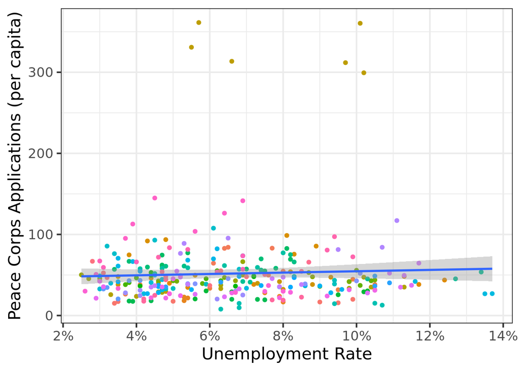

```r
ggplot(data = pc)+
    aes(x = unemployrate,
        y = appspc)+
    geom_point(aes(color = as.factor(state)))+
    geom_smooth(method = "lm")+
  scale_x_continuous(breaks=seq(0,20,2),
                     labels = function(x){paste(x,"%", sep="")})+
  labs(x = "Unemployment Rate",
       y = "Peace Corps Applications (per capita)")+
  theme_bw(base_family = "Fira Sans Condensed",
           base_size=16)+
  theme(legend.position = "none") # remove legend for State colors
```

We can see there are very clear outliers at the top. Let’s plot `text` instead of `point`s, using the `stateshort` to see which observations are which states:

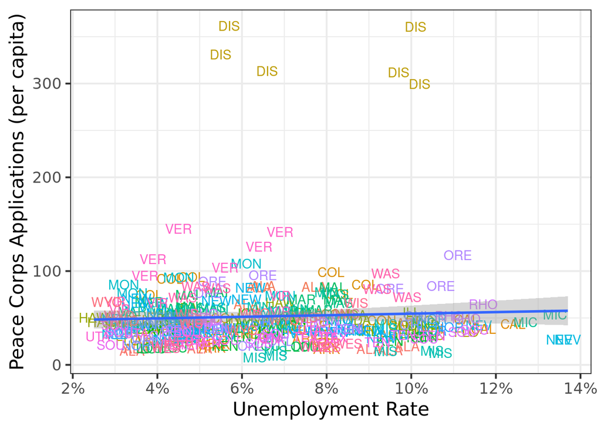

```r
ggplot(data = pc)+
    aes(x = unemployrate,
        y = appspc)+
    geom_text(aes(color = as.factor(state), label = stateshort))+ #<<
    geom_smooth(method = "lm")+
  scale_x_continuous(breaks=seq(0,20,2),
                     labels = function(x){paste(x,"%", sep="")})+
  labs(x = "Unemployment Rate",
       y = "Peace Corps Applications (per capita)")+
  theme_bw(base_family = "Fira Sans Condensed",
           base_size=16)+
  theme(legend.position = "none") # remove legend for State colors
```

Clearly `DIS`, which is District of Columbia, are the outliers. Let’s make a second scatterplot without them:

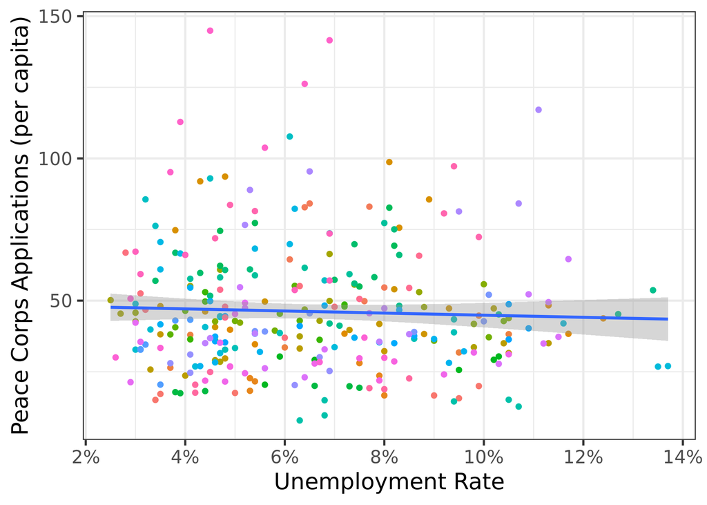

```r
pc %>%
  filter(state != "DISTRICT OF COLUMBIA") %>%
ggplot(data = .)+
    aes(x = unemployrate,
        y = appspc)+
    geom_point(aes(color = as.factor(state)))+
    geom_smooth(method = "lm")+
  scale_x_continuous(breaks=seq(0,20,2),
                     labels = function(x){paste(x,"%", sep="")})+
  labs(x = "Unemployment Rate",
       y = "Peace Corps Applications (per capita)")+
  theme_bw(base_family = "Fira Sans Condensed",
           base_size=16)+
  theme(legend.position = "none") # remove legend for State colors
```

### Part D

Run two *pooled* regressions, one with the outliers, and one without them. Write out the estimated regression equation for each. Interpret the coefficient, and comment on how it changes between the two regressions.

```r
pooled <- lm(appspc ~ unemployrate, data = pc)
summary(pooled)
```

```
Call:
lm(formula = appspc ~ unemployrate, data = pc)

Residuals:
    Min      1Q  Median      3Q     Max
-43.616 -20.641  -9.719   5.171 310.328

Coefficients:
             Estimate Std. Error t value Pr(>|t|)
(Intercept)   46.2255     7.2857   6.345 8.07e-10 ***
unemployrate   0.8353     1.0362   0.806    0.421
---
Signif. codes:  0 '***' 0.001 '**' 0.01 '*' 0.05 '.' 0.1 ' ' 1

Residual standard error: 45.2 on 304 degrees of freedom
Multiple R-squared:  0.002133,  Adjusted R-squared:  -0.00115
F-statistic: 0.6498 on 1 and 304 DF,  p-value: 0.4208
```

```r
pc_no_dc <- pc %>%
  filter(state != "DISTRICT OF COLUMBIA")

pooled_no_dc <- lm(appspc ~ unemployrate, data = pc_no_dc)
summary(pooled_no_dc)
```

```
Call:
lm(formula = appspc ~ unemployrate, data = pc_no_dc)

Residuals:
    Min      1Q  Median      3Q     Max
-38.380 -14.544  -4.190   9.278  97.997

Coefficients:
             Estimate Std. Error t value Pr(>|t|)
(Intercept)   48.5891     3.5955  13.514   <2e-16 ***
unemployrate  -0.3710     0.5133  -0.723     0.47
---
Signif. codes:  0 '***' 0.001 '**' 0.01 '*' 0.05 '.' 0.1 ' ' 1

Residual standard error: 22.17 on 298 degrees of freedom
Multiple R-squared:  0.001751,  Adjusted R-squared:  -0.001599
F-statistic: 0.5226 on 1 and 298 DF,  p-value: 0.4703
```

$$\widehat{\text{Apps per capita}_{it}}=48.59-0.37 \, \text{Unemployment Rate}_{it}$$

For every 1 percentage point increase in unemployment, there are 0.37 *fewer* applications to the Peace Corps per capita.

The coefficient changes signs and becomes a smaller magnitude by dropping the outliers (DC)!

### Part E

Now run a regression with State fixed effects using the dummy variable method. (Ensure that `state` is a factor variable, and insert in the regression. You can either `mutate()` it into a `factor` beforehand, or just do `factor(state)` in the `lm` command.) Interpret the marginal effect of `unemployrate` on `appspc`. How did it change?

```r
fe_reg <- lm(appspc ~ unemployrate + factor(state), data = pc)
summary(fe_reg)
```

```
Call:
lm(formula = appspc ~ unemployrate + factor(state), data = pc)

Residuals:
    Min      1Q  Median      3Q     Max
-31.652  -3.661  -0.393   3.492  33.262

Coefficients:
                                  Estimate Std. Error t value Pr(>|t|)
(Intercept)                        12.6070     3.7663   3.347 0.000939 ***
unemployrate                        0.6565     0.2330   2.817 0.005225 **
factor(state)ALASKA                52.5875     4.8452  10.854  < 2e-16 ***
factor(state)ARIZONA               18.0456     4.8463   3.724 0.000242 ***
factor(state)ARKANSAS               4.9117     4.8447   1.014 0.311630
factor(state)CALIFORNIA            22.1455     4.8692   4.548 8.39e-06 ***
factor(state)COLORADO              69.9201     4.8452  14.431  < 2e-16 ***
factor(state)CONNECTICUT           28.9349     4.8446   5.973 7.84e-09 ***
factor(state)DELAWARE              21.8317     4.8489   4.502 1.02e-05 ***
factor(state)DISTRICT OF COLUMBIA 311.7036     4.8533  64.225  < 2e-16 ***
factor(state)FLORIDA               13.0805     4.8492   2.697 0.007456 **
factor(state)GEORGIA               18.7073     4.8486   3.858 0.000145 ***
factor(state)HAWAII                35.7883     4.8617   7.361 2.53e-12 ***
factor(state)IDAHO                 34.4465     4.8480   7.105 1.21e-11 ***
factor(state)ILLINOIS              27.8559     4.8503   5.743 2.65e-08 ***
factor(state)INDIANA               21.5183     4.8478   4.439 1.35e-05 ***
factor(state)IOWA                  28.9038     4.8614   5.946 9.06e-09 ***
factor(state)KANSAS                28.9728     4.8507   5.973 7.83e-09 ***
factor(state)KENTUCKY               9.6535     4.8540   1.989 0.047800 *
factor(state)LOUISIANA              2.5206     4.8517   0.520 0.603844
factor(state)MAINE                 53.3394     4.8450  11.009  < 2e-16 ***
factor(state)MARYLAND              45.1903     4.8513   9.315  < 2e-16 ***
factor(state)MASSACHUSETTS         44.9452     4.8450   9.277  < 2e-16 ***
factor(state)MICHIGAN              26.8719     4.8970   5.487 9.86e-08 ***
factor(state)MINNESOTA             45.6153     4.8476   9.410  < 2e-16 ***
factor(state)MISSISSIPPI           -5.6364     4.8607  -1.160 0.247307
factor(state)MISSOURI              19.9421     4.8458   4.115 5.23e-05 ***
factor(state)MONTANA               66.2285     4.8583  13.632  < 2e-16 ***
factor(state)NEBRASKA              26.6913     4.8904   5.458 1.14e-07 ***
factor(state)NEVADA                12.7169     4.8767   2.608 0.009656 **
factor(state)NEW HAMPSHIRE         54.0272     4.8658  11.103  < 2e-16 ***
```

[output cut: 12 more lines]

```
factor(state)TENNESSEE              9.1572     4.8498   1.888 0.060142 .
factor(state)TEXAS                  9.2251     4.8455   1.904 0.058062 .
factor(state)UTAH                  18.8667     4.8571   3.884 0.000131 ***
factor(state)VERMONT              104.7363     4.8580  21.560  < 2e-16 ***
factor(state)VIRGINIA              46.9318     4.8607   9.655  < 2e-16 ***
factor(state)WASHINGTON            63.8660     4.8460  13.179  < 2e-16 ***
factor(state)WEST VIRGINIA          3.9514     4.8461   0.815 0.415620
factor(state)WISCONSIN             35.8930     4.8448   7.409 1.89e-12 ***
factor(state)WYOMING               35.3036     4.8665   7.254 4.88e-12 ***
---
Signif. codes:  0 '***' 0.001 '**' 0.01 '*' 0.05 '.' 0.1 ' ' 1

Residual standard error: 8.391 on 254 degrees of freedom
Multiple R-squared:  0.9713,    Adjusted R-squared:  0.9655
F-statistic: 168.4 on 51 and 254 DF,  p-value: < 2.2e-16
```

### Part F

Find the coefficient for Maryland and interpret it. How many applications per capita does Maryland have?

This is just like any model with dummy variables representing different categories. The constant (12.61) represents the *reference category* not put in the regression (to avoid the dummy variable trap), i.e. `ALABAMA.`

The coefficient on Maryland is 45.19. This means that, on average, there are 45.19 *more* applications per capita in Maryland *than Alabama* over the time period in the data. To get the average for Maryland, we add $12.61+45.19=57.80$.

```r
# if we want to extract it using R
fe_reg_tidy <- tidy(fe_reg)

AL <- fe_reg_tidy %>%
  filter(term == "(Intercept)") %>%
  pull(estimate)

MD_AL_diff <- fe_reg_tidy %>%
  filter(term == "factor(state)MARYLAND") %>%
  pull(estimate)

AL + MD_AL_diff
```

```
[1] 57.79731
```

### Part G

Now try using the `feols()` command (from the `fixest` package), which de-means the data, and make sure you get the same results as Part E. Do you get the same marginal effect of `unemployrate` on `appspc`?

```r
fe_reg_alt <- feols(appspc ~ unemployrate | factor(state),
                    data = pc)
summary(fe_reg_alt)
```

```
OLS estimation, Dep. Var.: appspc
Observations: 306
Fixed-effects: factor(state): 51
Standard-errors: Clustered (factor(state))
             Estimate Std. Error t value   Pr(>|t|)
unemployrate 0.656509   0.177444 3.69982 0.00053739 ***
---
Signif. codes:  0 '***' 0.001 '**' 0.01 '*' 0.05 '.' 0.1 ' ' 1
RMSE: 7.64486     Adj. R2: 0.965505
                Within R2: 0.0303
```

### Part H

Now also include *year* fixed effects in your regression, using the dummy variable method. Interpret the marginal effect of `unemployrate` on `appspc`. How did it change?

```r
TWFE_reg <- lm(appspc ~ unemployrate + factor(state) + factor(year), data = pc)
summary(TWFE_reg)
```

```
Call:
lm(formula = appspc ~ unemployrate + factor(state) + factor(year),
    data = pc)

Residuals:
     Min       1Q   Median       3Q      Max
-26.7457  -3.1669   0.1384   2.7666  31.1644

Coefficients:
                                   Estimate Std. Error t value Pr(>|t|)
(Intercept)                        14.48800    3.91879   3.697 0.000268 ***
unemployrate                        0.70525    0.54733   1.289 0.198760
factor(state)ALASKA                52.57126    4.08265  12.877  < 2e-16 ***
factor(state)ARIZONA               18.01801    4.09035   4.405 1.57e-05 ***
factor(state)ARKANSAS               4.91897    4.07940   1.206 0.229036
factor(state)CALIFORNIA            22.04317    4.23743   5.202 4.12e-07 ***
factor(state)COLORADO              69.93711    4.08307  17.129  < 2e-16 ***
factor(state)CONNECTICUT           28.93000    4.07894   7.093 1.36e-11 ***
factor(state)DELAWARE              21.87470    4.10713   5.326 2.24e-07 ***
factor(state)DISTRICT OF COLUMBIA 311.64268    4.13555  75.357  < 2e-16 ***
factor(state)FLORIDA               13.03582    4.10931   3.172 0.001702 **
factor(state)GEORGIA               18.66589    4.10502   4.547 8.50e-06 ***
factor(state)HAWAII                35.87361    4.18953   8.563 1.16e-15 ***
factor(state)IDAHO                 34.48472    4.10104   8.409 3.24e-15 ***
factor(state)ILLINOIS              27.80635    4.11635   6.755 1.00e-10 ***
factor(state)INDIANA               21.48091    4.10010   5.239 3.44e-07 ***
factor(state)IOWA                  28.98828    4.18745   6.923 3.75e-11 ***
factor(state)KANSAS                29.02399    4.11886   7.047 1.79e-11 ***
factor(state)KENTUCKY               9.59010    4.14017   2.316 0.021351 *
factor(state)LOUISIANA              2.57585    4.12547   0.624 0.532951
factor(state)MAINE                 53.35320    4.08152  13.072  < 2e-16 ***
factor(state)MARYLAND              45.24393    4.12277  10.974  < 2e-16 ***
factor(state)MASSACHUSETTS         44.95986    4.08187  11.015  < 2e-16 ***
factor(state)MICHIGAN              26.72242    4.41044   6.059 5.03e-09 ***
factor(state)MINNESOTA             45.65107    4.09827  11.139  < 2e-16 ***
factor(state)MISSISSIPPI           -5.71925    4.18336  -1.367 0.172813
factor(state)MISSOURI              19.91937    4.08656   4.874 1.95e-06 ***
factor(state)MONTANA               66.30488    4.16773  15.909  < 2e-16 ***
factor(state)NEBRASKA              26.83099    4.36996   6.140 3.24e-09 ***
factor(state)NEVADA                12.59989    4.28489   2.941 0.003585 **
```

[output cut: 18 more lines]

```
factor(state)WASHINGTON            63.84082    4.08836  15.615  < 2e-16 ***
factor(state)WEST VIRGINIA          3.97742    4.08900   0.973 0.331641
factor(state)WISCONSIN             35.90359    4.08029   8.799 2.35e-16 ***
factor(state)WYOMING               35.40021    4.22056   8.388 3.73e-15 ***
factor(year)2007                   -5.36842    1.39953  -3.836 0.000159 ***
factor(year)2008                    0.02018    1.48030   0.014 0.989135
factor(year)2009                    4.23877    2.61984   1.618 0.106939
factor(year)2010                   -3.25521    2.76284  -1.178 0.239836
factor(year)2011                   -8.88542    2.47990  -3.583 0.000409 ***
---
Signif. codes:  0 '***' 0.001 '**' 0.01 '*' 0.05 '.' 0.1 ' ' 1

Residual standard error: 7.064 on 249 degrees of freedom
Multiple R-squared:   0.98, Adjusted R-squared:  0.9756
F-statistic: 218.3 on 56 and 249 DF,  p-value: < 2.2e-16
```

For every 1 percentage point increase in the unemployment rate, there are 0.71 applications per capita to the Peace Corps.